# Time series *plastics* with Holt-Winters algorithms

Matthew O’Callaghan

2019

# 1 Plastics Data:

According to page 39 of the ‘fma’ package documentation we have the following information about the date we are using throughout this assignment:

- **Description**
  - Monthly sales of product A for a plastics manufacturer.
- **Usage**
  - plastics
- **Format**
  - Time series data

```r
# Importing forecasting package where plastics is contained and preferred plotting package:
require("fma")
require("ggplot2")
plastics
```

```
##    Jan  Feb  Mar  Apr  May  Jun  Jul  Aug  Sep  Oct  Nov  Dec
## 1  742  697  776  898 1030 1107 1165 1216 1208 1131  971  783
## 2  741  700  774  932 1099 1223 1290 1349 1341 1296 1066  901
## 3  896  793  885 1055 1204 1326 1303 1436 1473 1453 1170 1023
## 4  951  861  938 1109 1274 1422 1486 1555 1604 1600 1403 1209
## 5 1030 1032 1126 1285 1468 1637 1611 1608 1528 1420 1119 1013
```

The data is thus monthly, taken over a five year period. We assume all necessary Month Length Adjustments or Trading Day Adjustments have been made. Moreover we will assume that the value of sales indicates units sold.

# 2 Data Visualisation:

## 2.1 Time Plot

We first look at the full time-series plot of the data:

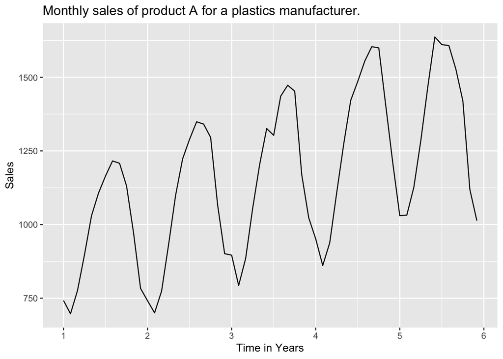

```r
autoplot(plastics) + ggtitle("Monthly sales of product A for a plastics manufacturer. ") +
  xlab("Time in Years") + ylab("Sales")
```

There are a few quilities which are evident from the time series plot:

- There is a clear seasonality which appears to be a yearly cycle.
  - The plot indicates an minimum around February at the start of each year, followed by a ramping period until it reaches its peak around September. This is then followed by a decrease in sales toward the end of each year.
  - This pattern could be due to the increased demand of retailers buying from a manufacturer to prepare for the Christmas period, then subsequently dropping in order to sell off existing stock.
- There is a steady upward trend.
  - This could reflect an increase in demand for the product from year to year.
- There are small visual irregularities in the time series: a sharp change near the end of year two and halfway through year three.
  - A possible explanation for sharp changes in the time-series could be a labour strike or adverse weather conditions preventing production.
- There is, of course, noise.

## 2.2 Seasonality and Trend Analysis:

The time-series plot indicates that there is seasonality. We now look at the seasonal plot and the seasonal subplot of the plastics data to further analyse these observations:

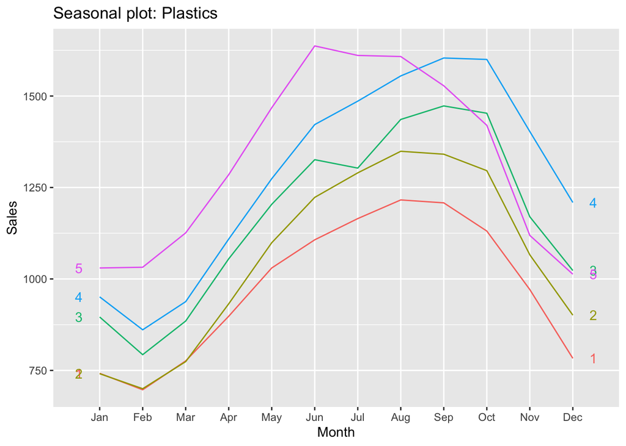

```r
ggseasonplot(plastics, year.labels=TRUE, year.labels.left=TRUE) +
  ylab("Sales") +
  ggtitle("Seasonal plot: Plastics")
```

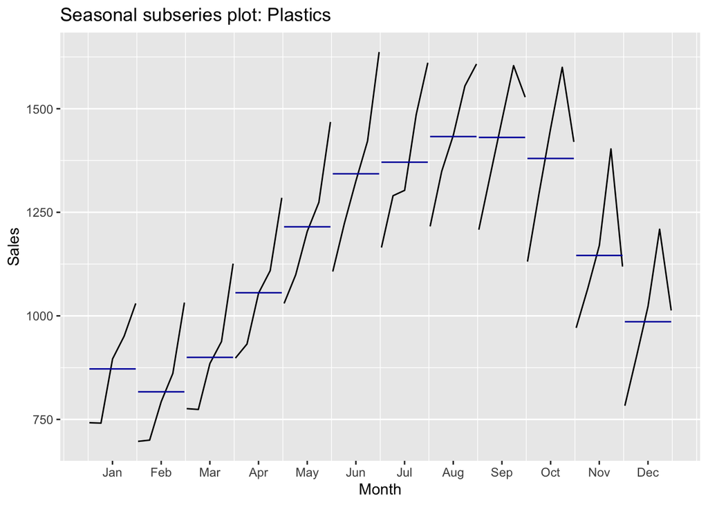

```r
ggsubseriesplot(plastics) +
  ylab("Sales") +
  ggtitle("Seasonal subseries plot: Plastics")
```

- The seaonal plot and the seasonal subseries plot reflects that the time-series displays significant seasonality with a period of 12 months.
  - The seasonal plot shows a similar shape for each year.
  - The seasonal subseries plot shows that the value at each month is trending upwards, the movement of the means (blue lines) from month to month reflects the seasonal pattern.
- The vertical movement of both plots up the y axis at each month confirms our visual inspection of increasing trend.
- The shape of the final year shows some inconsistency to this pattern.
  - This is seen in the seasonal subplot by the sharp decreases in the plot of Sep to Dec.
  - It is difficult to comment on this without further data. However, this may be due to product A becoming dated, the introduction of a competing manufacturer for a similar product or an increase in the cost of production in year five and thus becoming less lucrative to customers and subsequently retailers.

## 2.3 Autocorrelation:

We analyse the lagplot and the ACF to understand the correlation between the time-series and it’s lagged time-series.

First we consider the lag plot:

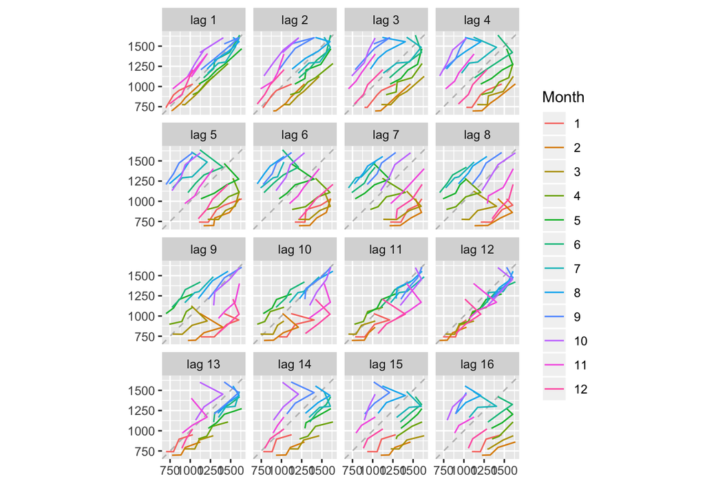

```r
gglagplot(plastics)
```

- The lag plot for a lag of 12 illustrates a strong correlation between values $y_t$ and $y_{t-12}$. This reflects the stong seasonality over a 12 month basis.
  - The changes in the plot from months 10 to 12 reflect the differences in year 5 seen in the seasonal subseries plot.
- The lag plot for lag 1 strenthens the idea that there is an increasing trend as it indicates a correlation between $y_t$ and $y_{t-1}$.

The autocorrelation function (AFC) measures the correlation between the time series and a lagged copy of itself. Now looking at the ACF plot:

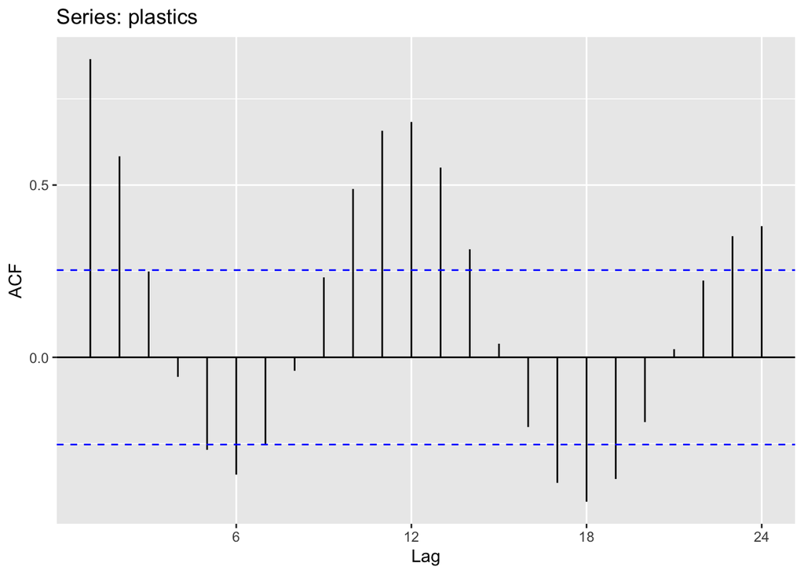

```r
ggAcf(plastics)
```

- The ACF has a large positive correlation for small lags, which confirms the trending nature of the data.
  - This is due to the fact that the ACF at lag 1 measures the correlation between successive values in the time series.
- The ACF at lag 12 is large and positive. This again confirms the 12 month seasonal nature of the data.
  - This is due to the fact that the ACF at lag 12 measures the correlation between $y_t$ and $y_{t-12}$ values in the time series.

Finally we plot our time series with a lag plot (of lag 12) overlayed:

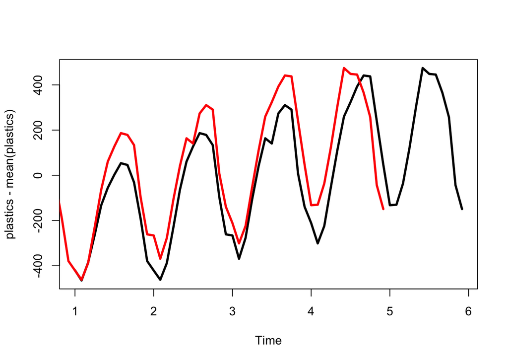

```r
plot(plastics-mean(plastics),lwd="3")
lines(lag(plastics-mean(plastics),12),col="red",lwd=3)
```

This confirms the information previously extracted from the data: we have a strong seasonal pattern and upward trend.

## 2.4 Decomposing the Time-Series:

We can decompose the time series in order to get a better understanding of the trend, seasonal and random component.

First we consider assume the additive model:
$$Y[t]=T[t]+S[t]+e(t)$$
where, throughout this section, $Y$ is the time series, $S$ is the seasonal component and $e$ is the random component; $t$ represents time.

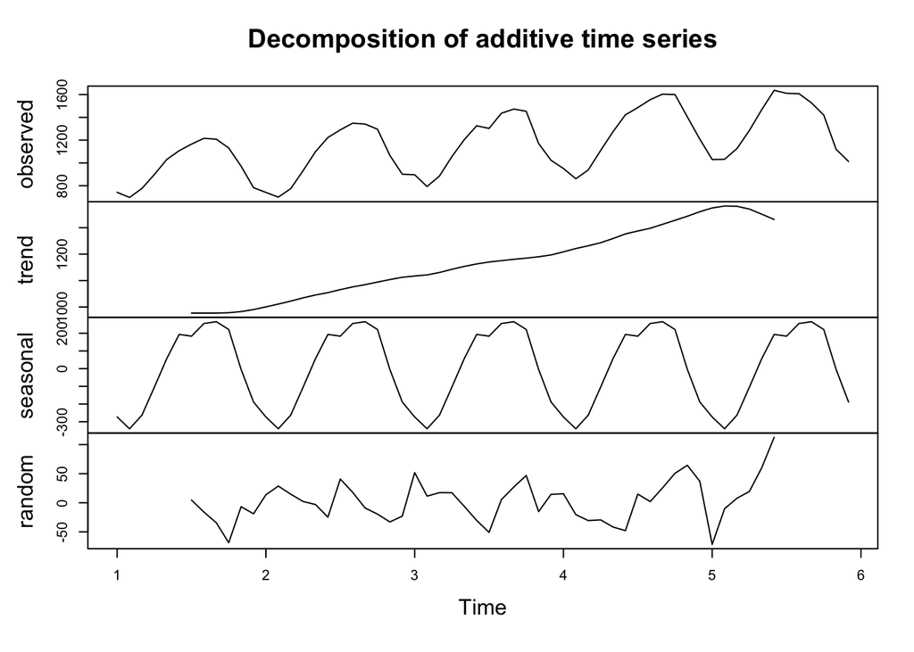

```r
plot(decompose(plastics))
```

Now we consider the multiplicative model:
$$Y[t]=T[t]\times S[t]\times e(t)$$

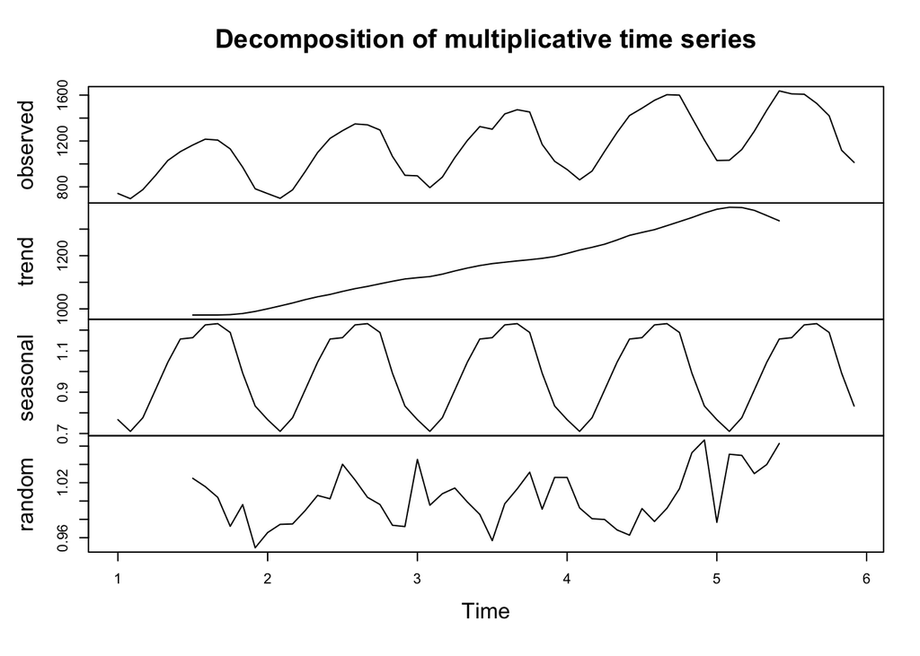

```r
plot(decompose(plastics,type="multiplicative"))
```

The decompositions agree with our understanding that there is an upward trend and a strong seasonal component. The change in the direction of the trend component during year five reflects the analysis in the seasonal plots.

Both the multiplicative and additive decompostion are very similar. To see which is more useful we can check the SSE of the model fit with both forms of decomposition.

## 2.5 Which algorithm to choose?

The information we have learned from the time-series visual analysis indicates that, because of the evident trend and seasonality, the best Holt-Winter algorithm to use will be the Holt-Winters’ Exponential Smoothing with Seasonality, as this algorithm utilises both trend and seasonality.

# 3 Fitting the Model

We begin by fitting the Holt-Winters’ Exponential Smoothing with Seasonality. Both the multiplicative model and the additive model will be tested. The best algorithm will be chosen based on which decomposition gives the smallest SSE in the fit. In this section we use the notation as in the [class notes](https://www.scss.tcd.ie/Rozenn.Dahyot/ST3010/RzDTimeSeriesForecasting.pdf): Chapter 8.

## 3.1 Fitting the Holt-Winters’ Exponential Smoothing with Seasonality

Here $\alpha, \beta, \gamma \in [0,1]$ are not predefined and the *HoltWinters()* R function selects them based on the value which minimises SSE.

Firstly we look at the multiplicative model:

```r
HoltWinters(plastics,seasonal = "multiplicative")
```

```
## Holt-Winters exponential smoothing with trend and multiplicative seasonal component.
##
## Call:
## HoltWinters(x = plastics, seasonal = "multiplicative")
##
## Smoothing parameters:
##  alpha: 0.8956671
##  beta : 0
##  gamma: 1
##
## Coefficients:
##             [,1]
## a   1240.0151515
## b      7.6462704
## s1     0.7445234
## s2     0.6970339
## s3     0.7616955
## s4     0.9018752
## s5     1.0508322
## s6     1.1673771
## s7     1.1923209
## s8     1.2496544
## s9     1.2448792
## s10    1.1769403
## s11    0.9821745
## s12    0.8169255
```

Which gives:
$$\alpha =0.8956671,\quad \beta=0,\quad \gamma=1$$
This implies that
$$b_t=b_{t-1}\\ S_t=\frac{y_t}{L_t}$$
Next the additive model:

```r
HoltWinters(plastics)
```

```
## Holt-Winters exponential smoothing with trend and additive seasonal component.
##
## Call:
## HoltWinters(x = plastics)
##
## Smoothing parameters:
##  alpha: 0.8597021
##  beta : 0
##  gamma: 1
##
## Coefficients:
##           [,1]
## a   1206.07798
## b      7.64627
## s1  -265.41477
## s2  -307.29099
## s3  -235.26285
## s4   -87.47203
## s5    66.03197
## s6   187.59170
## s7   194.26267
## s8   248.69599
## s9   240.59746
## s10  174.22956
## s11  -41.74172
## s12 -193.07798
```

Which gives:
$$\alpha =0.8597021,\quad \beta=0,\quad \gamma=1$$
This implies that
$$b_t=b_{t-1}\\ S_t=y_t-L_t$$

The zero value of $\beta$ then indicates that the slope component does not change over time. The value of $\gamma=1$ indicates that the seasonal component changes over time.

## 3.2 Model Comparison:

Now we compare the HW-Seasonality models by SSE:

```r
HoltWinters(plastics,seasonal = "multiplicative")$SSE
```

```
## [1] 116608.7
```

```r
HoltWinters(plastics)$SSE
```

```
## [1] 109774.7
```

Thus the SSE indicates that we should use the additive model.

It may be worthwhile to note that the MAPE of the two models:

```r
mean(abs(HoltWinters(plastics,seasonal = "multiplicative")$x - HoltWinters(plastics,seasonal = "multiplicative")$fitted)/HoltWinters(plastics,seasonal = "multiplicative")$x)
```

```
## [1] 0.5545592
```

```r
mean(abs(HoltWinters(plastics)$x - HoltWinters(plastics)$fitted)/HoltWinters(plastics)$x)
```

```
## [1] 0.5574668
```

indicate that the multiplicative model is better.

However going forward we shall use the additive model, based on SSE.

## 3.3 Predictions

### 3.3.1 Using the definition

```r
s=12 # frequency 12 month
Ln=HoltWinters(plastics, seasonal="additive")$coefficients[1]
bn=HoltWinters(plastics, seasonal="additive")$coefficients[2]
snk= HoltWinters(plastics, seasonal="additive")$coefficients[3]

for (k in 1:3) {
  cat("The forecast at month",k,"of year 6 is: ",(Ln+k*bn+snk),"\n")
}
```

```
## The forecast at month 1 of year 6 is:  948.3095
## The forecast at month 2 of year 6 is:  955.9557
## The forecast at month 3 of year 6 is:  963.602
```

### 3.3.2 Using the *predict()* function

We can also use the in-built *predict()* function:

```r
predict(HoltWinters(plastics, seasonal="additive"),n.ahead=1)[1]
```

```
## [1] 948.3095
```

```r
predict(HoltWinters(plastics, seasonal="additive"),n.ahead=2)[2]
```

```
## [1] 914.0795
```

```r
predict(HoltWinters(plastics, seasonal="additive"),n.ahead=3)[3]
```

```
## [1] 993.7539
```

### 3.3.3 Using the *forecast()* function

We can also use the in-built *forecast()* function:

```r
forecast(HoltWinters(plastics, seasonal="additive"),h=3)
```

```
##       Point Forecast    Lo 80     Hi 80    Lo 95    Hi 95
## Jan 6       948.3095 886.4804 1010.1386 853.7500 1042.869
## Feb 6       914.0795 832.5427  995.6164 789.3797 1038.779
## Mar 6       993.7539 896.4212 1091.0867 844.8963 1142.612
```

The dip in the upward trend of sales in the second half of year five influences the forecasted values of year six. Because of that dip, the forecasts for January, February and March are lower than the corresponding values in year five.

## 3.4 Plots of Forecast

We can plot the forecast:

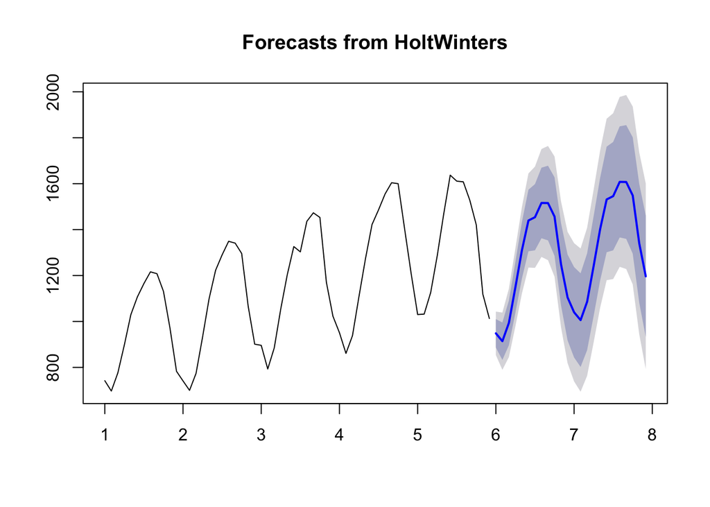

```r
plot(forecast(HoltWinters(plastics, seasonal="additive"), level=c(80,95)))
```

The dark shaded region shows 80% prediction intervals. That is, each future value is expected to lie in the dark shaded region with a probability of 80%. The light shaded region shows 95% prediction intervals. These prediction intervals are a useful way of displaying the uncertainty in forecasts.

The forecasted shape of year six is similar to that of year three. The forecast into year seven resumes the upward trend with respect to year six.

## 3.5 Residual Diagnostics

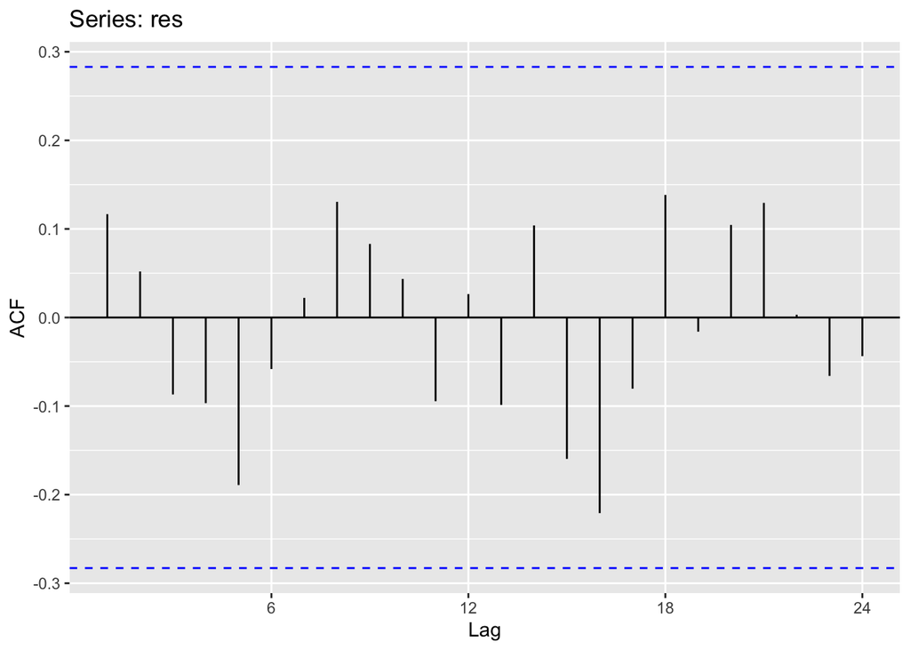

```r
res<-residuals(HoltWinters(plastics, seasonal="additive"))
ggAcf(res)
```

```r
mean(res)
```

```
## [1] -2.799251
```

This shows that our method produces a forecast that appear to account for all available information. The mean of the residuals is relatively close to zero and there is no significant correlation in the residuals. It resembles white noise.

# 4 Conclusion

The plastics data admits a clear upward trend and seasonality. We chose the Holt Winters Additive Model with Seasonality due to the fact it had the smallest SSE and used it to compute the forecast of the next three months. The algorithm predicted that the next three months will have values lower than that of the corrosponding months from the previous year.

# 5 Summary a

The Holt-Winters method has been used since 1957 to produce simple and effective short-term demand forecasts where the data contains a trend and a seasonal pattern. Since its conception, researchers have looked to extend the algorithm in three areas at which the original algorithm lacked: the influence of outliers, multiple seasonal cycles and utilising prediction intervals.

Outliers can cause problems for the Holt-Winters method as the estimates for the level, trend or seasonal pattern and the optimisation of the smoothing constants may be affected by them; leading to inaccurate forecasts. The method was extended by Sarah Gelper and her colleagues by an easily implemented mechanism which automatically identifies outliers and downgrades their influence. It identifies forecasts, with a one-step ahead error that exceeds a certain threshold, as outliers and replaces it with a cleaned value. This method has been shown to perform better than the Holt-Winters when outliers are present. It also preformed well when outliers weren’t present.

The Holt-Winters method wasn’t designed to deal with multiple seasonal cycles during the course of a year. The method was extended by James Taylor to deal with double and triple seasonal cycles by incorporating an additional smoothing constant and equations for each extra cycle. The triple-cycle method was more accurate than traditional Holt-Winters when tested on half-hourly electricity demand data. Its preformance was similar to that of n ARMA model designed for three seasonal cycles.

Prediction intervals for the Holt-Winters method underestimate the level of uncertainty there is when predicting the future. When fitting the model there is uncertainty in the smoothing constants and the initial values used in the Holt-Winters method. This has been extended by José D. Bermúdez et al., introducing a method that utilises a Bayesian framework which allows for uncertainty in the smoothing constants and initial values to be represented by probability distributions, which are updates as new data comes in. This method is complex but gave impressive results when tested.

# 6 Summary b

In ‘Statistical and Machine Learning forecasting methods: Concerns and ways forward’, Makridakis et al. illustrates that statistical methods are currently more dominant than Machine Learning(ML) methods in their practical applications to time-series forecasting. In particular, it’s interesting that the trade-off for using the computationally complex methods do not result in a more accurate forecast.

Forecasting methods are used in various commercial and scientific applications, therefore having a computationally easy method can be extremely important. For some short-term forecasts, compromising on accuracy for a model which takes less time to fit may be beneficial. Makridakis introduces two definitions when comparing computational complexity and forecasting accuracy. The computation complexity (CC) of fitting a model is defined as being the time taken to fit the model divided by the time taken to fit the naïve model to the dataset.
$$CC=\frac{Computational Time: Model}{Computational Time: Naïve}$$
The accuracy of the forecast is defined to be the sMAPE on the validation set.
$$sMAPE=\frac{2}{k} \sum_{t=1}^k \frac{|(Y_t-\hat{Y}_t)|}{(|Y_t|+|\hat{Y}_t|)} \times 100%$$
Where $k$ is the forecast horizon, $Y_t$,$\hat{Y}_t$ are actual and forecasted values, respectively.

Multiple ML and Statistical methods were fit to the 3003 time-series in order to see which would have more predictive power on a validation set. Makridakis found that the six most accurate forecasting methods were statistical. The only ML methods which outperformed the naïve benchmark were the BNN and MLP created by both Makridakis and Ahmed et al. The most accurate models were found to be ETS, ARIMA, Damped, Theta, SES and HoltWinters. Thus, knowing that ML algorithms are, in general, more computational complex than statistical ones, we expect the less complex statistical models will have a higher predictive power.

If we analyse the five statistical methods which give lowest sMAPE on the validation set, then the most computationally difficult of these are ARIMA and ETS, which outperform the easily computable Damped, Comb and Theta, but with very small margins. The computational complexity of ARIMA and ETS are significantly greater than the others, however ETS and ARIMA give an sMAPE of 7.12 and 7.19 respectively, while Damped, Comb and Theta give an sMAPE of 7.19, 7.20 and 7.23, respectively. ARIMA has the highest computational complexity but gives the same sMAPE as that of the Damped, which has one of the lowest CC values.

Solely analysing the ML methods leads to a similar result, the two methods which give the lowest sMAPE are the BNN and MLP; which have two of the highest computational complexity. However, if we look at the LSTM model we see it is of similar computational complexity but has a drastically different sMAPE (11.67 compared to 8.17). Moreover, the RBF which has the highest CC value only gives a sMAPE of 9.57. Thus we see that the higher end of the models to give the lowest sMAPE but equally complex models give much worse results. Comparing both classes, we see the best ML method, BNN, gives an sMAPE of 8.17, while the worst statistical method, HoltWinters, gives an sMAPE of 7.32; while BNN is far more complex than HoltWinters. In particular the highly computationally complex ML methods do not seem to be worth the higher computation time.

Thus, we see that choosing the most computationally complex model will not necessarily give us the most accurate forecast. In fact, opting for the computationally easy algorithms seems lucrative as the trade-off for higher complexity may not be rewarding.